# Diabetes

In this dataset you have 3 different outputs:

1. No readmission;
2. A readmission in less than 30 days (this situation is not good, because maybe your treatment was not appropriate);
3. A readmission in more than 30 days (this one is not so good as well the last one, however, the reason could be the state of the patient.  
   **Your task is either to classify a patient-hospital outcome or to cluster them aiming at finding patterns that give a distinct insight.**

This is a multiclass problem, where we are trying to predict 3 outputs. In aditional of the multiclas algorithm we will discover the features that has more impact in the prediction

All libraries are imported here:

```python
# Import libraries
import pandas as pd
import numpy as np
from sklearn.preprocessing import OrdinalEncoder
import seaborn as sns
import matplotlib.pyplot as plt
```

## 1. Exploration Data Analysis

```python
# Import data and get a first glance
diabetic_data = pd.read_csv('dataset_diabetes/dataset_diabetes/diabetic_data.csv')
print(diabetic_data.shape)
print(diabetic_data.columns)
diabetic_data.head()
```

```
(101766, 50)
Index(['encounter_id', 'patient_nbr', 'race', 'gender', 'age', 'weight',
       'admission_type_id', 'discharge_disposition_id', 'admission_source_id',
       'time_in_hospital', 'payer_code', 'medical_specialty',
       'num_lab_procedures', 'num_procedures', 'num_medications',
       'number_outpatient', 'number_emergency', 'number_inpatient', 'diag_1',
       'diag_2', 'diag_3', 'number_diagnoses', 'max_glu_serum', 'A1Cresult',
       'metformin', 'repaglinide', 'nateglinide', 'chlorpropamide',
       'glimepiride', 'acetohexamide', 'glipizide', 'glyburide', 'tolbutamide',
       'pioglitazone', 'rosiglitazone', 'acarbose', 'miglitol', 'troglitazone',
       'tolazamide', 'examide', 'citoglipton', 'insulin',
       'glyburide-metformin', 'glipizide-metformin',
       'glimepiride-pioglitazone', 'metformin-rosiglitazone',
       'metformin-pioglitazone', 'change', 'diabetesMed', 'readmitted'],
      dtype='object')
```

|  | encounter_id | patient_nbr | race | gender | age | weight | admission_type_id | discharge_disposition_id | admission_source_id | time_in_hospital | ... | citoglipton | insulin | glyburide-metformin | glipizide-metformin | glimepiride-pioglitazone | metformin-rosiglitazone | metformin-pioglitazone | change | diabetesMed | readmitted |
| --- | --- | --- | --- | --- | --- | --- | --- | --- | --- | --- | --- | --- | --- | --- | --- | --- | --- | --- | --- | --- | --- |
| 0 | 2278392 | 8222157 | Caucasian | Female | [0-10) | ? | 6 | 25 | 1 | 1 | ... | No | No | No | No | No | No | No | No | No | NO |
| 1 | 149190 | 55629189 | Caucasian | Female | [10-20) | ? | 1 | 1 | 7 | 3 | ... | No | Up | No | No | No | No | No | Ch | Yes | >30 |
| 2 | 64410 | 86047875 | AfricanAmerican | Female | [20-30) | ? | 1 | 1 | 7 | 2 | ... | No | No | No | No | No | No | No | No | Yes | NO |
| 3 | 500364 | 82442376 | Caucasian | Male | [30-40) | ? | 1 | 1 | 7 | 2 | ... | No | Up | No | No | No | No | No | Ch | Yes | NO |
| 4 | 16680 | 42519267 | Caucasian | Male | [40-50) | ? | 1 | 1 | 7 | 1 | ... | No | Steady | No | No | No | No | No | Ch | Yes | NO |

5 rows × 50 columns

```python
# Get general info of data
diabetic_data.info()
```

```
<class 'pandas.core.frame.DataFrame'>
RangeIndex: 101766 entries, 0 to 101765
Data columns (total 50 columns):
 #   Column                    Non-Null Count   Dtype
---  ------                    --------------   -----
 0   encounter_id              101766 non-null  int64
 1   patient_nbr               101766 non-null  int64
 2   race                      101766 non-null  object
 3   gender                    101766 non-null  object
 4   age                       101766 non-null  object
 5   weight                    101766 non-null  object
 6   admission_type_id         101766 non-null  int64
 7   discharge_disposition_id  101766 non-null  int64
 8   admission_source_id       101766 non-null  int64
 9   time_in_hospital          101766 non-null  int64
```

[output cut: 42 more lines]

There are no empty values but lets understand why.

```python
# Checking for missing values in dataset
for column in diabetic_data.columns:

    # Check for type of column
    if diabetic_data[column].dtype == object:

        # Get null values and different values for every column
        print(column,'different values: ', diabetic_data[column].nunique(), diabetic_data[column].unique()[:10])
```

```
race different values:  6 ['Caucasian' 'AfricanAmerican' '?' 'Other' 'Asian' 'Hispanic']
gender different values:  3 ['Female' 'Male' 'Unknown/Invalid']
age different values:  10 ['[0-10)' '[10-20)' '[20-30)' '[30-40)' '[40-50)' '[50-60)' '[60-70)'
 '[70-80)' '[80-90)' '[90-100)']
weight different values:  10 ['?' '[75-100)' '[50-75)' '[0-25)' '[100-125)' '[25-50)' '[125-150)'
 '[175-200)' '[150-175)' '>200']
payer_code different values:  18 ['?' 'MC' 'MD' 'HM' 'UN' 'BC' 'SP' 'CP' 'SI' 'DM']
medical_specialty different values:  73 ['Pediatrics-Endocrinology' '?' 'InternalMedicine'
 'Family/GeneralPractice' 'Cardiology' 'Surgery-General' 'Orthopedics'
 'Gastroenterology' 'Surgery-Cardiovascular/Thoracic' 'Nephrology']
diag_1 different values:  717 ['250.83' '276' '648' '8' '197' '414' '428' '398' '434' '250.7']
diag_2 different values:  749 ['?' '250.01' '250' '250.43' '157' '411' '492' '427' '198' '403']
diag_3 different values:  790 ['?' '255' 'V27' '403' '250' 'V45' '38' '486' '996' '197']
max_glu_serum different values:  4 ['None' '>300' 'Norm' '>200']
A1Cresult different values:  4 ['None' '>7' '>8' 'Norm']
metformin different values:  4 ['No' 'Steady' 'Up' 'Down']
repaglinide different values:  4 ['No' 'Up' 'Steady' 'Down']
nateglinide different values:  4 ['No' 'Steady' 'Down' 'Up']
chlorpropamide different values:  4 ['No' 'Steady' 'Down' 'Up']
glimepiride different values:  4 ['No' 'Steady' 'Down' 'Up']
acetohexamide different values:  2 ['No' 'Steady']
glipizide different values:  4 ['No' 'Steady' 'Up' 'Down']
glyburide different values:  4 ['No' 'Steady' 'Up' 'Down']
tolbutamide different values:  2 ['No' 'Steady']
pioglitazone different values:  4 ['No' 'Steady' 'Up' 'Down']
rosiglitazone different values:  4 ['No' 'Steady' 'Up' 'Down']
acarbose different values:  4 ['No' 'Steady' 'Up' 'Down']
miglitol different values:  4 ['No' 'Steady' 'Down' 'Up']
troglitazone different values:  2 ['No' 'Steady']
tolazamide different values:  3 ['No' 'Steady' 'Up']
examide different values:  1 ['No']
citoglipton different values:  1 ['No']
insulin different values:  4 ['No' 'Up' 'Steady' 'Down']
glyburide-metformin different values:  4 ['No' 'Steady' 'Down' 'Up']
glipizide-metformin different values:  2 ['No' 'Steady']
glimepiride-pioglitazone different values:  2 ['No' 'Steady']
metformin-rosiglitazone different values:  2 ['No' 'Steady']
metformin-pioglitazone different values:  2 ['No' 'Steady']
change different values:  2 ['No' 'Ch']
diabetesMed different values:  2 ['No' 'Yes']
readmitted different values:  3 ['NO' '>30' '<30']
```

In this case null values where saved as '?' or unknown/valid

```python
# Checking for missing values in dataset
for column in diabetic_data.columns:

    # Check for percentage of null values
    if '?' in diabetic_data[column].unique():
        count = diabetic_data[column][diabetic_data[column] == '?'].count()
        print(column, count, f'{round(count/len(diabetic_data)*100)}%')
```

```
race 2273 2%
weight 98569 97%
payer_code 40256 40%
medical_specialty 49949 49%
diag_1 21 0%
diag_2 358 0%
diag_3 1423 1%
```

```python
# Gender have 'Unkonwn/Invalid' for null
print('gender', diabetic_data['gender'][diabetic_data['gender'] == 'Unknown/Invalid'].count())
```

```
gender 3
```

Most of 'weight','payer_code','medical_specialty' are null values and 'citoglipton', 'examide' have the same value for ever row, then we can drop those columns, for diag1,2,3 there are fewer values then we drop the rows.

## 2. Data Cleaning and Feature Engineering

It is hard to do feature engineering if we have no knowledge about the dataset. It is important to communicate with an expert to do the best preprocessing to different features. In this case we will only do one hot encoding and binary transformation. It's important that the number of observations is bigger than the number of features.

### 2.1 Object Data Type

```python
# Dropping columns with large number of missing values
diabetic_data = diabetic_data.drop(columns = ['weight','payer_code','medical_specialty', 'citoglipton', 'examide'])

# Dropping rows wih diag_1,2,3 being null
df = diabetic_data[diabetic_data['diag_1'] != '?']
df = df[df['diag_2'] != '?']
df = df[df['diag_3'] != '?']
df = df[df['race'] != '?']
df = df[df['gender'] != 'Unknown/Invalid']
```

```python
# Checking for missing values in dataset
for column in df.columns:

    # Check for percentage of null values
    if '?' in df[column].unique():
        count = df[column][df[column] == '?'].count()
        print(column, count, f'{round(count/len(df)*100)}%')
```

```python
# Checking for different values in dataset
for column in df.columns:

    # Check for type of column
    if df[column].dtype == object:

        # Get null values and different values for every column
        print(column,'different values: ', df[column].nunique(), df[column].unique()[:10])
```

```
race different values:  5 ['Caucasian' 'AfricanAmerican' 'Other' 'Asian' 'Hispanic']
gender different values:  2 ['Female' 'Male']
age different values:  10 ['[10-20)' '[20-30)' '[30-40)' '[40-50)' '[50-60)' '[60-70)' '[70-80)'
 '[80-90)' '[90-100)' '[0-10)']
diag_1 different values:  713 ['276' '648' '8' '197' '414' '428' '398' '434' '250.7' '157']
diag_2 different values:  740 ['250.01' '250' '250.43' '157' '411' '492' '427' '198' '403' '288']
diag_3 different values:  786 ['255' 'V27' '403' '250' 'V45' '38' '486' '996' '197' '250.6']
max_glu_serum different values:  4 ['None' '>300' 'Norm' '>200']
A1Cresult different values:  4 ['None' '>7' '>8' 'Norm']
metformin different values:  4 ['No' 'Steady' 'Up' 'Down']
repaglinide different values:  4 ['No' 'Up' 'Steady' 'Down']
nateglinide different values:  4 ['No' 'Steady' 'Down' 'Up']
chlorpropamide different values:  4 ['No' 'Steady' 'Down' 'Up']
glimepiride different values:  4 ['No' 'Steady' 'Down' 'Up']
acetohexamide different values:  2 ['No' 'Steady']
glipizide different values:  4 ['No' 'Steady' 'Up' 'Down']
glyburide different values:  4 ['No' 'Steady' 'Up' 'Down']
tolbutamide different values:  2 ['No' 'Steady']
pioglitazone different values:  4 ['No' 'Steady' 'Up' 'Down']
rosiglitazone different values:  4 ['No' 'Steady' 'Up' 'Down']
acarbose different values:  4 ['No' 'Steady' 'Up' 'Down']
miglitol different values:  4 ['No' 'Steady' 'Down' 'Up']
troglitazone different values:  2 ['No' 'Steady']
tolazamide different values:  3 ['No' 'Steady' 'Up']
insulin different values:  4 ['Up' 'No' 'Steady' 'Down']
glyburide-metformin different values:  4 ['No' 'Steady' 'Down' 'Up']
glipizide-metformin different values:  2 ['No' 'Steady']
glimepiride-pioglitazone different values:  2 ['No' 'Steady']
metformin-rosiglitazone different values:  1 ['No']
metformin-pioglitazone different values:  2 ['No' 'Steady']
change different values:  2 ['Ch' 'No']
diabetesMed different values:  2 ['Yes' 'No']
readmitted different values:  3 ['>30' 'NO' '<30']
```

```python
# Droping one more column
df = df.drop(columns = 'metformin-rosiglitazone')
```

Now let's do one hot encoding for features with more that 2 different values, annd the ones with only 2 we are going to transform it into binary data

```python
# One Hot Encoding
columns = ['race', 'age', 'max_glu_serum', 'A1Cresult', 'metformin', 'repaglinide', 'nateglinide', 'chlorpropamide', 'glimepiride', 'pioglitazone', 'rosiglitazone',
           'acarbose', 'miglitol', 'tolazamide', 'insulin', 'glyburide-metformin', 'glipizide', 'glyburide', 'readmitted']

# Generate dummies for every column and append
for column in columns:
    one_hot = pd.get_dummies(df[column], prefix = column)
    df = pd.concat([df, one_hot], axis=1)

# Drop previous columns
columns = ['race', 'age', 'max_glu_serum', 'A1Cresult', 'metformin', 'repaglinide', 'nateglinide', 'chlorpropamide', 'glimepiride', 'pioglitazone', 'rosiglitazone',
           'acarbose', 'miglitol', 'tolazamide', 'insulin', 'glyburide-metformin', 'glipizide', 'glyburide']
df = df.drop(columns=columns)
```

```python
# Categorical encoding
columns = ['gender', 'acetohexamide', 'tolbutamide', 'troglitazone', 'glipizide-metformin',
           'glimepiride-pioglitazone', 'metformin-pioglitazone', 'change', 'diabetesMed', 'readmitted']


# Apply binary encoding for every column
enc = OrdinalEncoder()
enc.fit(df[columns])
df[columns] = enc.transform(df[columns])

#df['readmitted'] = df['readmitted'].replace('>30', 0)
#df['readmitted'] = df['readmitted'].replace('<30', 1)
#df['readmitted'] = df['readmitted'].replace('NO', 0)
```

```python
print(df.shape)
df[columns].head()
```

```
(98052, 107)
```

|  | gender | acetohexamide | tolbutamide | troglitazone | glipizide-metformin | glimepiride-pioglitazone | metformin-pioglitazone | change | diabetesMed | readmitted |
| --- | --- | --- | --- | --- | --- | --- | --- | --- | --- | --- |
| 1 | 0.0 | 0.0 | 0.0 | 0.0 | 0.0 | 0.0 | 0.0 | 0.0 | 1.0 | 1.0 |
| 2 | 0.0 | 0.0 | 0.0 | 0.0 | 0.0 | 0.0 | 0.0 | 1.0 | 1.0 | 2.0 |
| 3 | 1.0 | 0.0 | 0.0 | 0.0 | 0.0 | 0.0 | 0.0 | 0.0 | 1.0 | 2.0 |
| 4 | 1.0 | 0.0 | 0.0 | 0.0 | 0.0 | 0.0 | 0.0 | 0.0 | 1.0 | 2.0 |
| 5 | 1.0 | 0.0 | 0.0 | 0.0 | 0.0 | 0.0 | 0.0 | 1.0 | 1.0 | 1.0 |

### 2.2 Numeric Data Type

Now its time to cleaning data that is numeric, let's observe if doing one hot encoding is worthed.

```python
# Checking for different values in dataset
for column in df.columns:

    # Check for type of column
    if df[column].dtype == np.int64:

        # Get null values and different values for every column
        print(column,'different values: ', df[column].nunique(), df[column].unique()[:10])
```

```
encounter_id different values:  98052 [149190  64410 500364  16680  35754  55842  63768  12522  15738  28236]
patient_nbr different values:  68629 [ 55629189  86047875  82442376  42519267  82637451  84259809 114882984
  48330783  63555939  89869032]
admission_type_id different values:  8 [1 2 3 6 4 5 8 7]
discharge_disposition_id different values:  26 [ 1  3  6  2  5 11  7 25 10  4]
admission_source_id different values:  17 [ 7  2  4  1  5  6 20  3 17  8]
time_in_hospital different values:  14 [ 3  2  1  4  5 13 12  9  7 10]
num_lab_procedures different values:  118 [59 11 44 51 31 70 73 68 33 47]
num_procedures different values:  7 [0 5 1 6 2 3 4]
num_medications different values:  75 [18 13 16  8 21 12 28 17 11 15]
number_outpatient different values:  39 [ 0  2  1  5  7  9  3  8  4 12]
number_emergency different values:  33 [0 1 4 2 3 9 7 5 6 8]
number_inpatient different values:  20 [0 1 2 3 6 5 4 7 8 9]
number_diagnoses different values:  14 [ 9  6  7  5  8  3  4 16 12 13]
```

```python
# Let's drop nnique identifiers
df = df.drop(columns =['encounter_id', 'patient_nbr'])
```

```python
#Function to count null values depending on null indicator
def check_null(df:pd.DataFrame, column:str, indicator:list):
    for i in indicator:
        count = df[column][df[column] == i].count()
        print(column, count, f'{round(count/len(df)*100)}%', f'indicator = {i}')
```

```python
# Checking for missing values in dataset
columns = [['admission_type_id', [5, 6, 8]], ['discharge_disposition_id', [18,25,16]], ['admission_source_id', [9, 15, 17, 20, 21]]]
for column in columns:
    check_null(df, column[0], column[1])
```

```
admission_type_id 4661 5% indicator = 5
admission_type_id 5135 5% indicator = 6
admission_type_id 312 0% indicator = 8
discharge_disposition_id 3624 4% indicator = 18
discharge_disposition_id 941 1% indicator = 25
discharge_disposition_id 11 0% indicator = 16
admission_source_id 49 0% indicator = 9
admission_source_id 0 0% indicator = 15
admission_source_id 6602 7% indicator = 17
admission_source_id 160 0% indicator = 20
admission_source_id 0 0% indicator = 21
```

There is some null values, but if if drop them we are gonna loose a lot of information, then I am gonna drop only rows from nulls with 1% or less.

```python
# Dropping rows 1% or less null values
df = df[df['admission_type_id'] != 8]
df = df[df['discharge_disposition_id'] != 25]
df = df[df['discharge_disposition_id'] != 16]
df = df[df['admission_source_id'] != 9]
df = df[df['admission_source_id'] != 15]
df = df[df['admission_source_id'] != 20]
df = df[df['admission_source_id'] != 21]
```

```python
df.shape
```

```
(96581, 105)
```

Now let us change the ids columns for one hot encoding

```python
# One Hot Encoding
columns = ['admission_type_id', 'discharge_disposition_id', 'admission_source_id']

# Generate dummies for every column and append
for column in columns:
    one_hot = pd.get_dummies(df[column], prefix = column)
    df = pd.concat([df, one_hot], axis=1)

# Drop previous columns
df = df.drop(columns=columns)
```

```python
print(df.shape)
df.head()
```

```
(96581, 148)
```

|  | gender | time_in_hospital | num_lab_procedures | num_procedures | num_medications | number_outpatient | number_emergency | number_inpatient | diag_1 | diag_2 | ... | admission_source_id_6 | admission_source_id_7 | admission_source_id_8 | admission_source_id_10 | admission_source_id_11 | admission_source_id_13 | admission_source_id_14 | admission_source_id_17 | admission_source_id_22 | admission_source_id_25 |
| --- | --- | --- | --- | --- | --- | --- | --- | --- | --- | --- | --- | --- | --- | --- | --- | --- | --- | --- | --- | --- | --- |
| 1 | 0.0 | 3 | 59 | 0 | 18 | 0 | 0 | 0 | 276 | 250.01 | ... | 0 | 1 | 0 | 0 | 0 | 0 | 0 | 0 | 0 | 0 |
| 2 | 0.0 | 2 | 11 | 5 | 13 | 2 | 0 | 1 | 648 | 250 | ... | 0 | 1 | 0 | 0 | 0 | 0 | 0 | 0 | 0 | 0 |
| 3 | 1.0 | 2 | 44 | 1 | 16 | 0 | 0 | 0 | 8 | 250.43 | ... | 0 | 1 | 0 | 0 | 0 | 0 | 0 | 0 | 0 | 0 |
| 4 | 1.0 | 1 | 51 | 0 | 8 | 0 | 0 | 0 | 197 | 157 | ... | 0 | 1 | 0 | 0 | 0 | 0 | 0 | 0 | 0 | 0 |
| 5 | 1.0 | 3 | 31 | 6 | 16 | 0 | 0 | 0 | 414 | 411 | ... | 0 | 0 | 0 | 0 | 0 | 0 | 0 | 0 | 0 | 0 |

5 rows × 148 columns

```python
df.info()
```

```
<class 'pandas.core.frame.DataFrame'>
Int64Index: 96581 entries, 1 to 101765
Columns: 148 entries, gender to admission_source_id_25
dtypes: float64(10), int64(8), object(3), uint8(127)
memory usage: 27.9+ MB
```

### 2.3 Diagnosis preprocessing

**Original Diabetes Paper**

Diagnosis 1 Nominal The primary diagnosis (coded as first three digits of ICD9); 848 distinct values

Diagnosis 2 Nominal Secondary diagnosis (coded as first three digits of ICD9); 923 distinct values

Diagnosis 3 Nominal Additional secondary diagnosis (coded as first three digits of ICD9); 954 distinct values

diag 1-3 are string values, we should change them to numeric type

It is extremely hard to include every different diagnosis in the model, therefore, based on the anbstract of the paper I decided only to use the primary diagnosis.

```python
# Dropping columns
df = df.drop(columns = ['diag_2', 'diag_3'])
```

[figure not shown]

```python
# Create new columns
df['Circulatory'] = 0
df['Respiratory'] = 0
df['Digestive'] = 0
df['Diabetes'] = 0
df['Injury'] = 0
df['Musculoskeletal'] = 0
df['Genitourinary'] = 0
df['Neoplasms'] = 0
df['Other'] = 0

# Transform E–V to number
df.loc[df['diag_1'].str.contains('V'), ['diag_1']] = '0'
df.loc[df['diag_1'].str.contains('E'), ['diag_1']] = '0'

# convert column to numeric
df["diag_1"] = pd.to_numeric(df["diag_1"])
```

```python
# Fill column based on icd9 codes
for idx, obs in df.iterrows():
    if (obs['diag_1'] >= 390 and obs['diag_1'] <= 459) or obs['diag_1'] == 785:
        df.loc[idx, 'Circulatory'] = 1

    elif (obs['diag_1'] >= 460 and obs['diag_1'] <= 519) or obs['diag_1'] == 786:
        df.loc[idx, 'Respiratory'] = 1

    elif (obs['diag_1'] >= 520 and obs['diag_1'] <= 579) or obs['diag_1'] == 787:
        df.loc[idx, 'Digestive'] = 1

    elif obs['diag_1'] == 250:
        df.loc[idx, 'Diabetes'] = 1

    elif obs['diag_1'] >= 800 and obs['diag_1'] <= 999:
        df.loc[idx, 'Injury'] = 1

    elif obs['diag_1'] >= 710 and obs['diag_1'] <= 739:
        df.loc[idx, 'Musculoskeletal'] = 1

    elif (obs['diag_1'] >= 580 and obs['diag_1'] <= 629) or obs['diag_1'] == 788:
        df.loc[idx, 'Genitourinary'] = 1

    elif obs['diag_1'] >= 140 and obs['diag_1'] <= 239:
        df.loc[idx, 'Neoplasms'] = 1

    else:
        df.loc[idx, 'Other'] = 1
```

```python
# Dropping column
df = df.drop(columns = 'diag_1')
```

Let's check the datatypes one more time

```python
df.info()
```

```
<class 'pandas.core.frame.DataFrame'>
Int64Index: 96581 entries, 1 to 101765
Columns: 154 entries, gender to Other
dtypes: float64(10), int64(17), uint8(127)
memory usage: 34.3 MB
```

```python
print(df.shape)
df.head()
```

```
(96581, 154)
```

|  | gender | time_in_hospital | num_lab_procedures | num_procedures | num_medications | number_outpatient | number_emergency | number_inpatient | number_diagnoses | acetohexamide | ... | admission_source_id_25 | Circulatory | Respiratory | Digestive | Diabetes | Injury | Musculoskeletal | Genitourinary | Neoplasms | Other |
| --- | --- | --- | --- | --- | --- | --- | --- | --- | --- | --- | --- | --- | --- | --- | --- | --- | --- | --- | --- | --- | --- |
| 1 | 0.0 | 3 | 59 | 0 | 18 | 0 | 0 | 0 | 9 | 0.0 | ... | 0 | 0 | 0 | 0 | 0 | 0 | 0 | 0 | 0 | 1 |
| 2 | 0.0 | 2 | 11 | 5 | 13 | 2 | 0 | 1 | 6 | 0.0 | ... | 0 | 0 | 0 | 0 | 0 | 0 | 0 | 0 | 0 | 1 |
| 3 | 1.0 | 2 | 44 | 1 | 16 | 0 | 0 | 0 | 7 | 0.0 | ... | 0 | 0 | 0 | 0 | 0 | 0 | 0 | 0 | 0 | 1 |
| 4 | 1.0 | 1 | 51 | 0 | 8 | 0 | 0 | 0 | 5 | 0.0 | ... | 0 | 0 | 0 | 0 | 0 | 0 | 0 | 0 | 1 | 0 |
| 5 | 1.0 | 3 | 31 | 6 | 16 | 0 | 0 | 0 | 9 | 0.0 | ... | 0 | 1 | 0 | 0 | 0 | 0 | 0 | 0 | 0 | 0 |

5 rows × 154 columns

```python
count = df['readmitted_<30'][df['readmitted_<30'] == 1].count()
print('readmitted_<30', count)
count = df['readmitted_>30'][df['readmitted_>30'] == 1].count()
print('readmitted_>30', count)
count = df['readmitted_NO'][df['readmitted_NO'] == 1].count()
print('readmitted_NO', count)
```

```
readmitted_<30 10918
readmitted_>30 34114
readmitted_NO 51549
```

```python
df['readmitted'].value_counts()
```

```
2.0    51549
1.0    34114
0.0    10918
Name: readmitted, dtype: int64
```

## 3. Correlation Analysis

Let's do a correlation analysis for those variables that we want to predict

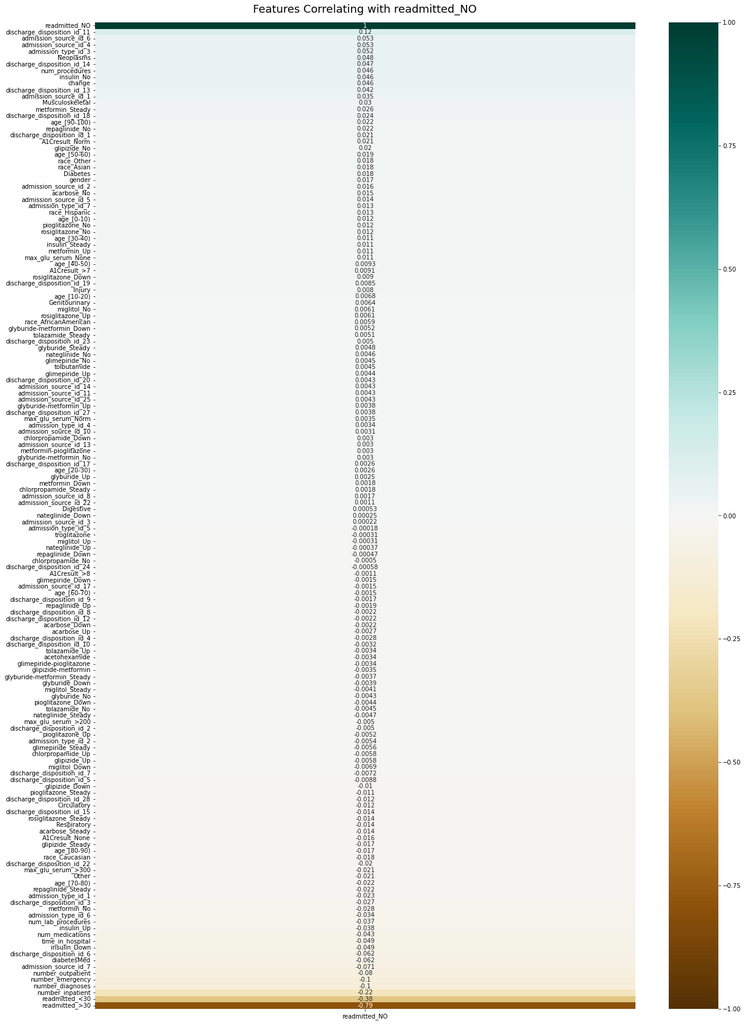

```python
plt.figure(figsize=(20, 30))
heatmap = sns.heatmap(df.corr()[['readmitted_NO']].sort_values(by='readmitted_NO', ascending=False), vmin=-1, vmax=1, annot=True, cmap='BrBG')
heatmap.set_title('Features Correlating with readmitted_NO', fontdict={'fontsize':18}, pad=16);

plt.savefig('correlation_readmitted_NO.png', dpi=300, bbox_inches='tight')
```

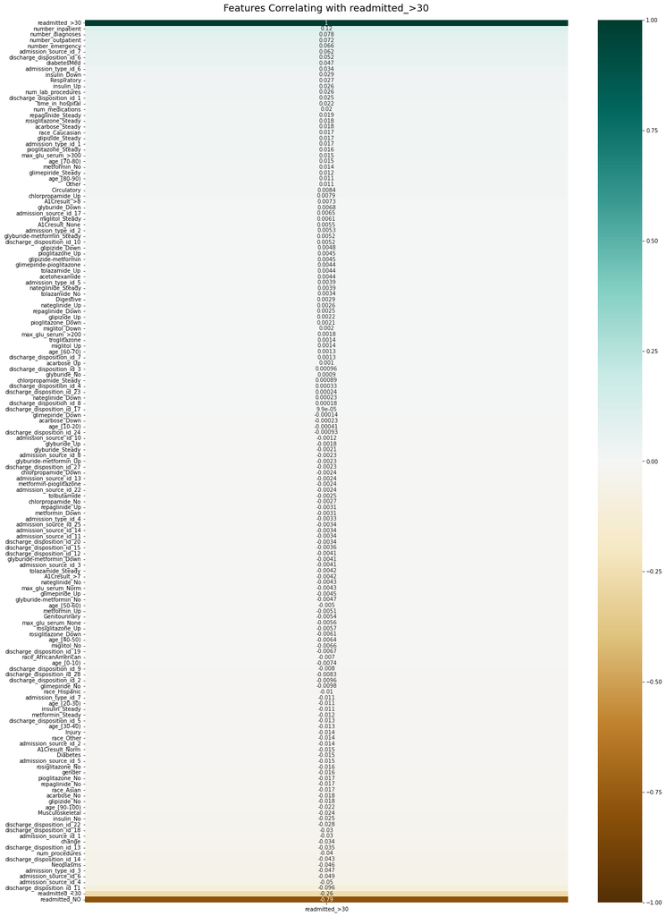

```python
plt.figure(figsize=(20, 30))
heatmap = sns.heatmap(df.corr()[['readmitted_>30']].sort_values(by='readmitted_>30', ascending=False), vmin=-1, vmax=1, annot=True, cmap='BrBG')
heatmap.set_title('Features Correlating with readmitted_>30', fontdict={'fontsize':18}, pad=16);

plt.savefig('correlation_readmitted_morethan30.png', dpi=300, bbox_inches='tight')
```

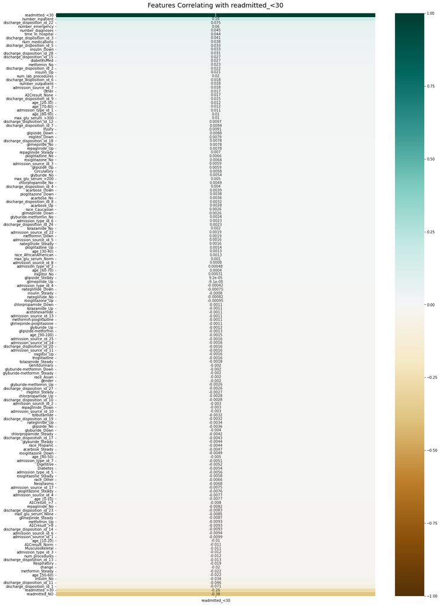

```python
plt.figure(figsize=(20, 30))
heatmap = sns.heatmap(df.corr()[['readmitted_<30']].sort_values(by='readmitted_<30', ascending=False), vmin=-1, vmax=1, annot=True, cmap='BrBG')
heatmap.set_title('Features Correlating with readmitted_<30', fontdict={'fontsize':18}, pad=16);

plt.savefig('correlation_readmitted_lessthan30.png', dpi=300, bbox_inches='tight')
```

## 4. Training

For training the models I will use random search for hyperparameter tunning, cross validation and kfold for model selection.

### 4.1 Cross Validation

```python
# Define target columns
drop_columns = ['readmitted_>30', 'readmitted_<30', 'readmitted_NO', 'readmitted']

# Define training matrix and target
X = df.drop(columns = drop_columns)
y = df['readmitted']

print('X ', X.shape)
print('y ', y.shape)
```

```
X  (96581, 150)
y  (96581,)
```

```python
from sklearn.model_selection import train_test_split
x_train, x_test, y_train, y_test = train_test_split(X, y, test_size=0.2, shuffle=True)
print(x_train.shape)
print(x_test.shape)
```

```
(77264, 150)
(19317, 150)
```

### 4.2 Classifiers

```python
from sklearn.metrics import accuracy_score, recall_score, precision_score, f1_score, confusion_matrix
from sklearn.model_selection import StratifiedKFold, GridSearchCV, RandomizedSearchCV
import warnings; warnings.filterwarnings('ignore')
from matplotlib.colors import ListedColormap
from sklearn import metrics
```

```python
def run_classifier(clf, param_grid, title):
    # -----------------------------------------------------
    cv = StratifiedKFold(n_splits= 3, shuffle = True, random_state= 123)

    # Randomized grid search
    n_iter_search = 1
    gs = RandomizedSearchCV(clf,
                            param_distributions = param_grid,
                            n_iter = n_iter_search,
                            cv = cv,
                            scoring= 'accuracy')
    # -----------------------------------------------------
    # Train model
    gs.fit(x_train, y_train)
    print("The best parameters are %s" % (gs.best_params_))

    # Predict on test set
    y_pred = gs.best_estimator_.predict(x_test)

    # Get Probability estimates
    y_prob = gs.best_estimator_.predict_proba(x_test)[:, 1]
    # -----------------------------------------------------
    print('Accuracy score: %.2f%%' %(accuracy_score(y_test, y_pred)*100))
    print('Precision score: %.2f%%' % (precision_score(y_test, y_pred, average='weighted')*100))
    print('Recall score: %.2f%%' % (recall_score(y_test, y_pred, average='weighted')*100))
    print('F1 score: %.2f%%' % (f1_score(y_test, y_pred, average='weighted')*100))
    # -----------------------------------------------------
    # Plot confusion matrix
    fig, ax = plt.subplots()
    cm = confusion_matrix(y_test, y_pred)#, labels= target_names)
    sns.heatmap(cm, annot = True, cbar = False, fmt = "d", linewidths = .5, cmap = "Blues", ax = ax)
    ax.set_title("Confusion Matrix")
    ax.set_xlabel("Predicted class")
    ax.set_ylabel("Actual class")
    fig.tight_layout()

    if title == 'Random Forest' or  title =='Decision Tree' or  title =='XGBoost':
        # Create list of top most features based on importance
        feature_names = x_train.columns
        feature_imports = gs.best_estimator_.feature_importances_
        most_imp_features = pd.DataFrame([f for f in zip(feature_names,feature_imports)], columns=["Feature", "Importance"]).nlargest(10, "Importance")
        most_imp_features.sort_values(by="Importance", inplace=True)
        plt.figure(figsize=(10,6))
        plt.barh(range(len(most_imp_features)), most_imp_features.Importance, align='center', alpha=0.8)
        plt.yticks(range(len(most_imp_features)), most_imp_features.Feature, fontsize=14)
        plt.xlabel('Importance')
        plt.title(f'Most important features - {title} ')
        plt.show()
```

### 4.2 Classical Neural Network

```python
from keras.models import Sequential
from keras.layers import Dense
from keras.wrappers.scikit_learn import KerasClassifier
from sklearn.preprocessing import LabelEncoder
from sklearn.pipeline import Pipeline
```

```python
# create model
model = Sequential()
model.add(Dense(64, input_dim=X.shape[1], activation='relu'))
model.add(Dense(1, activation='sigmoid'))
```

```
dict_keys(['loss', 'binary_accuracy', 'val_loss', 'val_binary_accuracy'])
```

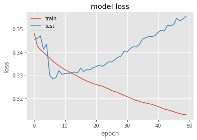

```python
# Training the model
epochs_num = 50

model.compile(loss=tf.losses.BinaryCrossentropy(),
              optimizer=tf.optimizers.Adam(),
              metrics=[tf.metrics.BinaryAccuracy()])


history = model.fit(x_train,
                    y_train,
                    epochs=50,
                    callbacks=None,
                    validation_data=(x_test, y_test),
                    shuffle=False)

# list all data in history
print(history.history.keys())

# summarize history for loss
plt.style.use("ggplot")
plt.figure()
plt.plot(history.history['loss'])
plt.plot(history.history['val_loss'])
plt.title('model loss')
plt.ylabel('loss')
plt.xlabel('epoch')
plt.legend(['train', 'test'], loc='upper left')
plt.show()
```

### 4.2 Logistic Regression

```
The best parameters are {'solver': 'lbfgs', 'penalty': 'l2'}
Accuracy score: 57.45%
Precision score: 53.82%
Recall score: 57.45%
F1 score: 50.93%
```

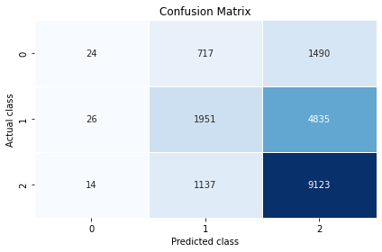

```python
from sklearn.linear_model import LogisticRegression

lr = LogisticRegression()

param_grid = {'penalty': ['l2'],
              'solver': ['newton-cg', 'lbfgs', 'liblinear', 'sag', 'saga']}

run_classifier(lr, param_grid, 'Logistic Regression')
```

### 4.3 K-Nearest Neighbors algorithm (k-NN)

```
The best parameters are {'weights': 'distance', 'n_neighbors': 1, 'leaf_size': 5, 'algorithm': 'auto'}
Accuracy score: 45.80%
Precision score: 45.11%
Recall score: 45.80%
F1 score: 45.43%
```

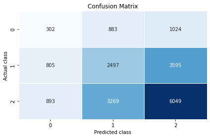

```python
from sklearn.neighbors import KNeighborsClassifier

knn = KNeighborsClassifier()

param_grid = {'n_neighbors': np.arange(1,15),
             'weights': ['uniform', 'distance'],
             'leaf_size':[1, 3, 5],
             'algorithm':['auto', 'kd_tree']}

run_classifier(knn, param_grid, 'Nearest Neighbors')
```

### 4.4 Naive Bayes

[output not shown]

[figure not shown]

```python
from sklearn.naive_bayes import GaussianNB

nb = GaussianNB()

param_grid = {'priors': [None]}

run_classifier(nb, param_grid, 'Naive Bayes')
```

### 4.5 Decision Tree

```
The best parameters are {'splitter': 'random', 'min_samples_split': 2, 'min_samples_leaf': 1, 'max_features': None, 'max_depth': 13, 'criterion': 'entropy'}
Accuracy score: 56.76%
Precision score: 53.22%
Recall score: 56.76%
F1 score: 51.76%
```

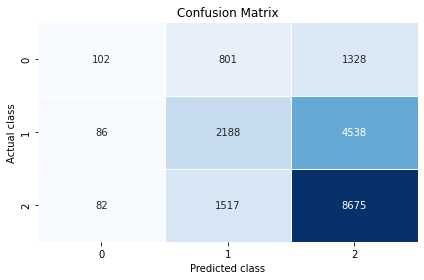

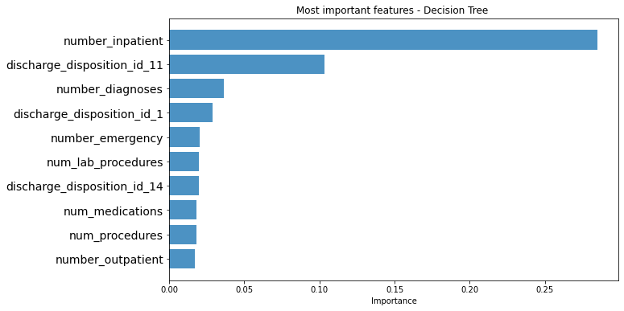

```python
from sklearn.tree import DecisionTreeClassifier

dtree = DecisionTreeClassifier()

param_grid = {'criterion': ['gini', 'entropy'],
              'splitter': ['best', 'random'],
              'max_depth': np.arange(1, 20, 2),
              'min_samples_split': [2, 5, 10],
              'min_samples_leaf': [1, 2, 4, 10],
              'max_features': ['auto', 'sqrt', 'log2', None]}

run_classifier(dtree, param_grid, "Decision Tree")
```

### 4.6 Random Forest

```
The best parameters are {'n_estimators': 100, 'min_samples_split': 10, 'min_samples_leaf': 10, 'max_features': None, 'max_depth': 20, 'criterion': 'entropy', 'bootstrap': True}
Accuracy score: 57.93%
Precision score: 55.64%
Recall score: 57.93%
F1 score: 53.18%
```

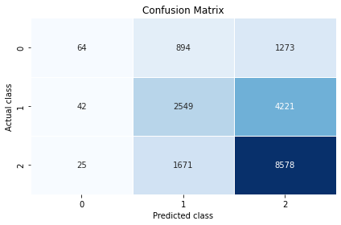

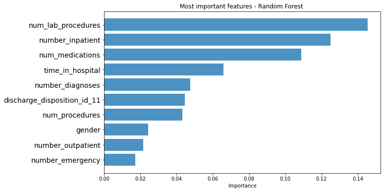

```python
from sklearn.ensemble import RandomForestClassifier

rf = RandomForestClassifier()

param_grid = {'n_estimators': [100, 200],
              'max_depth': [10, 20, 100, None],
              'max_features': ['auto', 'sqrt', None],
              'min_samples_split': [2, 5, 10],
              'min_samples_leaf': [1, 2, 4, 10],
              'bootstrap': [True, False],
              'criterion': ['gini', 'entropy']}

run_classifier(rf, param_grid, 'Random Forest')
```

### 4.7 Multi-layer Perceptron

```
The best parameters are {'solver': 'adam', 'max_iter': 100, 'learning_rate': 'adaptive', 'hidden_layer_sizes': (10,), 'alpha': 10.0, 'activation': 'relu'}
Accuracy score: 55.44%
Precision score: 47.79%
Recall score: 55.44%
F1 score: 45.45%
```

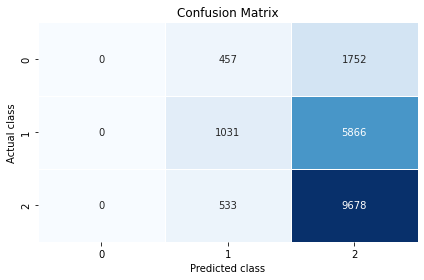

```python
from sklearn.neural_network import MLPClassifier

mlp = MLPClassifier()

param_grid = {'hidden_layer_sizes': [(10,), (50,), (10, 10), (50, 50)],
             'activation': ['identity', 'logistic', 'tanh', 'relu'],
             'solver': ['adam'],
             'alpha': np.logspace(-5, 3, 5),
             'learning_rate': ['constant', 'invscaling','adaptive'],
             'max_iter': [100, 500, 1000]}

run_classifier(mlp, param_grid, 'Neural Net')
```

### 4.8 XGBoost

```
The best parameters are {'n_estimators': 100}
Accuracy score: 58.00%
Precision score: 55.18%
Recall score: 58.00%
F1 score: 52.76%
```

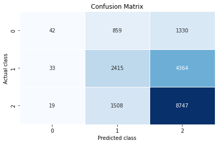

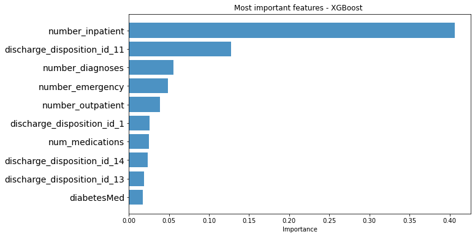

```python
from sklearn.ensemble import GradientBoostingClassifier as xgbost

xgb = xgbost()

param_grid = {'n_estimators': [100]}

run_classifier(xgb, param_grid, 'XGBoost')
```